# Predicting rideshare demand in New York City

Zhenzhao Xu

```r
knitr::opts_chunk$set(
    message = FALSE,
    warning = FALSE,
    results=FALSE,
    fig.align="center",
    cache=T
)
```

```r
library(tidyverse)
library(tidycensus)
library(sf)
library(kableExtra)
library(patchwork)
library(ggplot2)
# library(RSocrata)
library(viridis)
# library(spatstat)
# library(caret)
# library(stargazer)
#library(raster)
#library(spdep)
# library(FNN)
# library(grid)
library(gridExtra)
library(knitr)
# library(plotROC)
# library(pROC)

library(lubridate)
library(tigris)
library(gganimate)
library(riem)

options(scipen=999)
options(tigris_class = "sf")
options(tigris_use_cache = TRUE)
source("functions.r")

p5 = inferno(5)
p2 = p5[c(4,2)]
p5_2 = viridis::viridis(5)

v = mapview::mapview

crs = 3623
```

## 1. Introduction

Bike share is a shared transport service in which bicycles are made available for shared use to individuals on a short term basis for a price or free. Many bike share systems allow people to borrow a bike from a “dock” and return it at another dock belonging to the same system. Bike share technology has evolved over the course of decades, and development of programs has grown exponentially.

City Bike is the largest share bike company in New York City, with 20,357 bicycles on city streets and 41,763 docks where they can be parked, which means that every neighborhood in Manhattan now has Citi Bike docks — and the network is one of the world’s largest bike-sharing services. And this network is still growing as the pandemic turns many New Yorkers away from mass transit. Cycling in New York City grew by as much as 30% last year, according to New York City Transportation Department data.

A key to success for a bike sharing systems is the effectiveness of re-balancing operations, that is, the efforts of restoring the number of bikes in each station to its target value to satisfy the underlying demands. Under this circumstance, the ability to predict users’ supply and demand in both spatial and temporal dimensions is of great importance. Thus, in this project, the goal is to predicting ride share demand in New York City with time and spatial data.

## 2. Data wrangling and feature engineering

The data source of this project is listed as follows:

1. Bike share (2019-8) - https://ride.citibikenyc.com/system-data
2. Weather - from R library `riem`
3. ACS - American Chemical Society
4. Commercial Zoning by lot - https://data.cityofnewyork.us/Business/Primary-Commercial-Zoning-by-lot/pwhj-ikym
5. Open spaces - https://data.cityofnewyork.us/Recreation/Open-Space-Parks-/g84h-jbjm
6. Bus stops - https://data.cityofnewyork.us/Transportation/Bus-Stop-Shelters/qafz-7myz
7. Subway stations - https://data.cityofnewyork.us/Transportation/Subway-Stations/arq3-7z49
8. Bike routes - https://data.cityofnewyork.us/Transportation/Bicycle-Routes/7vsa-caz7
9. Neighborhoods - https://data.cityofnewyork.us/City-Government/2010-Neighborhood-Tabulation-Areas-NTAs-/cpf4-rkhq

### 2.1 Loading bike data

```r
# The initial code to process the data
# It's very slow so processed data is loaded instead.

# bike.full = read.csv('data/201908-citibike-tripdata.csv')%>%
#   select(tripduration,starttime,start.station.id,
#          start.station.longitude,start.station.latitude,
#          usertype,gender,birth.year)
# bike.full%>%dim()
```

The structure of the bike dataset is shown as follows.

| Column | Name | Explanation | Type |
| --- | --- | --- | --- |
| Trip Duration | tripduration | seconds | int |
| Start Time and Date | starttime |  | date |
| Stop Time and Date | stoptime |  | date |
| Start Station Name | start.station.name |  | str |
| End Station Name | end.station.name |  | str |
| Station ID | start.station.id / end.station.id |  | str |
| Station Lat/Long | start.station.latitude / start.station.longitude |  | dbl |
| Bike ID | bikeid |  | int |
| User Type | usertype | Customer = 24-hour pass or 3-day pass user; Subscriber = Annual Member | str |
| Gender | gender | Zero=unknown; 1=male; 2=female | int |
| Year of Birth | birth.year |  | int |

Because of the fact that the regression is going to be run on the scale of bike docks, the detailed information, like Bike ID, is not used.

### 2.2 Subsetting the dataset

The original dataset of City Bike is large, there are more than 2 million rides in Aug, 2019 in New York City. Because of the limited calculatioin power, the research area is restricted in South Manhattan, and the detailed region is shown as follows.

```r
# restrict the neighborhoods into South Manhattan
nbh_list = "Turtle Bay-East Midtown,Midtown-Midtown South,Clinton,Hudson Yards-Chelsea-Flatiron-Union Square,Gramercy,Stuyvesant Town-Cooper Village,Lower East Side,East Village,West Village,SoHo-TriBeCa-Civic Center-Little Italy,Battery Park City-Lower Manhattan,Chinatown,Murray Hill-Kips Bay"%>%
  strsplit(",")%>%.[[1]]

nbh = st_read("data/neighborhood.geojson")%>%
  filter(ntaname %in% nbh_list)%>%
  select(ntaname)%>%
  rename(nname=ntaname)%>%
  st_transform(crs)

boundary = nbh %>% st_union()

# bike = bike.full%>%
#   st_as_sf(coords=c("start.station.longitude",
#                     "start.station.latitude"),
#            crs=4326) %>% st_sf()%>%
#   st_transform(crs=crs)%>%
#   filter(st_within(.,nbh%>%st_union(),sparse = F))
#
# bike%>%st_write("data/bike_processed.geojson",append=F)
# bike = bike %>%
#   filter(st_within(.,nbh%>%st_union(),sparse = F))

bike = st_read("data/bike_processed.geojson") %>%
  mutate(interval60 = floor_date(ymd_hms(starttime), unit = "hour"),
         interval15 = floor_date(ymd_hms(starttime), unit = "15 mins"),
         week = week(interval60),
         dotw = wday(interval60, label=TRUE))

bike.geom = bike%>%
  group_by(start.station.id)%>%
  summarise(geometry=st_sfc(first(geometry)))%>%
  select(start.station.id,geometry)%>%
  st_sf(crs=crs)
```

```r
v(boundary,color=p5[3],lwd=2,alpha.regions=0,col.regions=p5[3])+
v(bike.geom,legend =F,color=p5[3],alpha.regions=0,cex=2)
```

[interactive chart not shown]

The pre-processed bike data is used to accelerate the knit process, but all processing procedure is shown.

### 2.3 Create the space/time panel

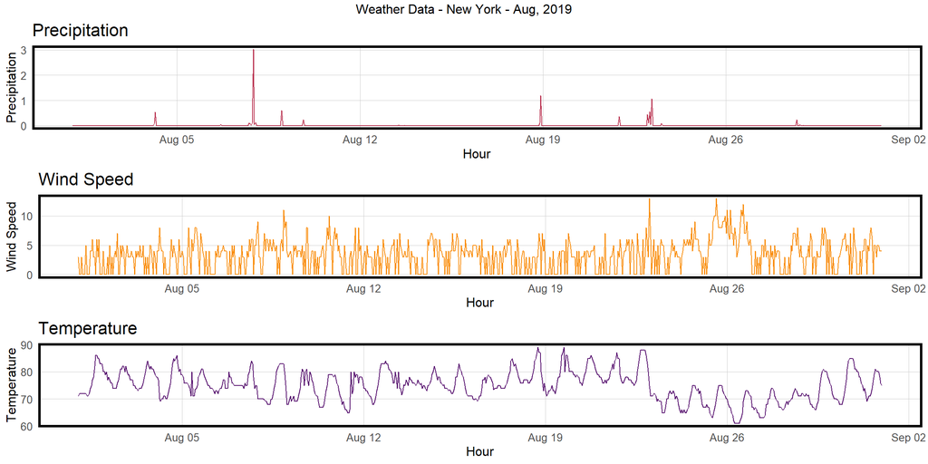

```r
weather = riem_measures(station = "NYC",date_start = '2019-08-01' ,date_end = '2019-09-01')
weather.panel = weather%>%
    mutate_if(is.character, list(~replace(as.character(.), is.na(.), "0"))) %>%
    replace(is.na(.), 0) %>%
    mutate(interval60 = ymd_h(substr(valid, 1, 13))) %>%
    mutate(week = week(interval60),
           dotw = wday(interval60, label=TRUE)) %>%
    group_by(interval60) %>%
    summarize(Temperature = max(tmpf),
              Precipitation = sum(p01i),
              Wind_Speed = max(sknt)) %>%
    mutate(Temperature = ifelse(Temperature == 0, 80, Temperature))

grid.arrange(top = "Weather Data - New York - Aug, 2019",
  ggplot(weather.panel, aes(interval60,Precipitation)) + geom_line(color=p5[3]) +
    labs(title="Precipitation", x="Hour", y="Precipitation") + plotTheme(),
  ggplot(weather.panel, aes(interval60,Wind_Speed)) + geom_line(color=p5[4]) +
    labs(title="Wind Speed", x="Hour", y="Wind Speed") + plotTheme(),
  ggplot(weather.panel, aes(interval60,Temperature)) + geom_line(color=p5[2]) +
    labs(title="Temperature", x="Hour", y="Temperature") + plotTheme())
```

The weather data is collect and grouped by each hour. Three aspects of the weather, precipitation, temperature, and wind speed are collected.

```r
study.panel =
  expand.grid(interval60 = unique(bike$interval60),
              start.station.id = unique(bike$start.station.id))
nrow(study.panel)

ride.panel =
  bike %>%
    st_drop_geometry()%>%
    mutate(Trip_Counter = 1) %>%
    right_join(study.panel,by=c("interval60","start.station.id")) %>%
    group_by(interval60, start.station.id) %>%
    summarize(Trip_Count = sum(Trip_Counter, na.rm=T))

ride.panel = ride.panel%>%
  left_join(weather.panel, by = "interval60") %>%
  left_join(bike.geom)%>%
  mutate(week = week(interval60),
         dotw = wday(interval60, label = TRUE)) %>%
  st_sf()
```

A space/time panel of the stations are created. Time interval is set to 60 min, and the total panel size is equal to 24*31*254=188976 unique space/time units.

### 2.4 Feature engineering

Weather and time effects are added to the model. Time effect is created as `lagHour`, `lag2Hour`, `lag3Hour`, `lag4Hour`, `lag12Hour`, and `lag1Day`.

```r
ride.panel =
  ride.panel %>%
    arrange(start.station.id, interval60) %>%
    group_by(start.station.id) %>%
    mutate(lagHour = dplyr::lag(Trip_Count,1),
           lag2Hours = dplyr::lag(Trip_Count,2),
           lag3Hours = dplyr::lag(Trip_Count,3),
           lag4Hours = dplyr::lag(Trip_Count,4),
           lag12Hours = dplyr::lag(Trip_Count,12),
           lag1day = dplyr::lag(Trip_Count,24)) %>%
   ungroup()
```

Amenities are also taken into account, like bus stops, bike route, commercial area, park, and subway stations. Point-level data like bus stops and subway stations are transformed as the distance from bike docks to the nearest point. Polygons and lines are calculated as the density within certain distance of bike docks.

```r
bus = st_read("./data/bus.geojson")%>%
  st_transform(crs)%>%
  filter(st_within(.,boundary,sparse = F))%>%
  select(geometry)

bike_route =  st_read("./data/bike-routes.geojson")%>%
  st_transform(crs)%>%
  st_intersection(boundary)%>%
  select(geometry)%>%
  st_union()%>%st_sf()

commercial =  st_read("./data/commercial_lot.geojson")%>%
  st_transform(crs)%>%
  st_intersection(boundary)%>%
  select(geometry)%>%
  st_union()%>%
  st_sf()

park =  st_read("./data/park.geojson")%>%
  st_transform(crs)%>%
  st_intersection(boundary)%>%
  select(geometry)%>%
  st_union()%>%
  st_simplify()

subway =  st_read("./data/subway.geojson")%>%
  st_transform(crs)%>%
  st_intersection(boundary)%>%
  select(geometry)

nn1=function(g1,g2,k){return(nn_function(st_coordinates(g1),st_coordinates(g2),k))}

polygon_area_in_point_buffer=function(point,polygon,distance){
  area = point%>%
    st_buffer(distance)%>%st_sf(crs=crs)%>%
    st_intersection(polygon)
  area = ifelse(nrow(area)>0,st_area(area)%>%as.double(),0)
  return(area)
}

line_length_in_point_buffer=function(point,line,distance){
  return(point%>%
    st_buffer(distance)%>%st_sf(crs=crs)%>%
    st_intersection(line)%>%
    st_length()%>%as.numeric())
}

# ride.panel.engineer = ride.panel %>% rowwise()%>%
#   mutate(
#     expo.subway=nn1(geometry,subway,1),
#     expo.bus=nn1(geometry,bus,1),
#     expo.commercial=polygon_area_in_point_buffer(geometry,commercial,500),
#     expo.park=polygon_area_in_point_buffer(geometry,park,500),
#     expo.bike_route=line_length_in_point_buffer(geometry,bike_route,500),
#   )

ride.panel.engineer = st_read("./data/ride.engineer.geojson")
```

### 2.5 Split training and test sets

```r
ride.Train = filter(ride.panel.engineer, week <= 33) # 31,32,33
ride.Test = filter(ride.panel.engineer, week > 33) # 34,35
```

Two datasets are created in this step to do both cross-validation and normal validation:

1. 3-week training set and a 2-week test
2. complete 5 week panel

## 3. Exploratory analysis plot

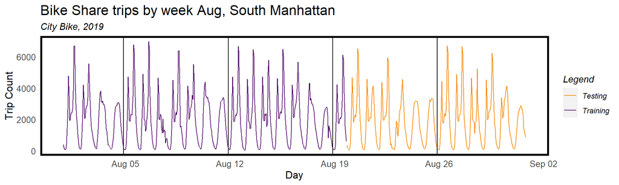

```r
mondays =
  mutate(ride.panel,
         monday = ifelse(dotw == "Mon" & hour(interval60) == 1,
                         interval60, 0)) %>%
  filter(monday != 0)

st_drop_geometry(rbind(
  mutate(ride.Train, Legend = "Training"),
  mutate(ride.Test, Legend = "Testing"))) %>%
    group_by(Legend, interval60) %>%
      summarize(Trip_Count = sum(Trip_Count)) %>%
      ungroup() %>%
      ggplot(aes(interval60, Trip_Count, colour = Legend)) + geom_line() +
        scale_colour_manual(values = p2) +
        geom_vline(data = mondays, aes(xintercept = monday)) +
        labs(title="Bike Share trips by week Aug, South Manhattan",
             subtitle="City Bike, 2019",
             x="Day", y="Trip Count") +
        plotTheme() + theme(panel.grid.major = element_blank())
```

From the above figure, the number of Bike Share has periodic feature: within a week, the number of trips in Monday to Friday is more, the number of weekends is more smooth, and the overall demand is less than working days; and within one day, the demand during the day is greater than the night, and there is extreme needs during the morning and evening peak.

```r
plotData.lag =
  filter(as.data.frame(ride.panel), week == 33) %>%
  dplyr::select(starts_with("lag"), Trip_Count) %>%
  gather(Variable, Value, -Trip_Count) %>%
  mutate(Variable = fct_relevel(Variable, "lagHour","lag2Hours","lag3Hours",
                                          "lag4Hours","lag12Hours","lag1day"))
correlation.lag <-
  group_by(plotData.lag, Variable) %>%
    summarize(correlation = round(cor(Value, Trip_Count, use = "complete.obs"), 2))
```

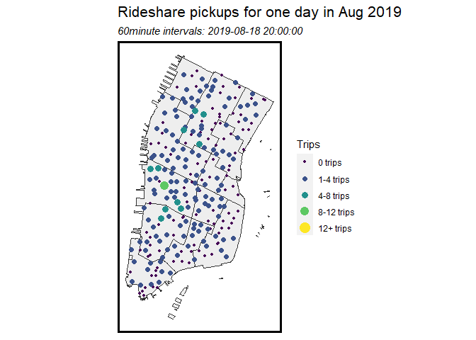

```r
ride.animation.data=
  filter(ride.panel.engineer , week == 33 & dotw == "Mon")%>%
    st_sf() %>%
    mutate(Trips = case_when(Trip_Count == 0 ~ "0 trips",
                             Trip_Count > 0 & Trip_Count <= 4 ~ "1-4 trips",
                             Trip_Count > 4 & Trip_Count <= 8 ~ "4-8 trips",
                             Trip_Count > 8 & Trip_Count <= 12 ~ "8-12 trips",
                             Trip_Count > 12 ~ "12+ trips")) %>%
    mutate(Trips  = fct_relevel(Trips, "0 trips","1-4 trips","4-8 trips",
                                       "8-12 trips","12+ trips"))
rideshare_animation = ride.animation.data%>%
  st_sf(crs=crs)%>%
  ggplot() +
    geom_sf(data=nbh,fill="#eeeeee",color="#333333",size=.5)+
    geom_sf(aes(color = Trips,size=Trips)) +
    scale_color_manual(values = p5_2 ) +
    scale_size_manual(values =1:5) +
    labs(title = "Rideshare pickups for one day in Aug 2019",
         subtitle = "60minute intervals: {current_frame}") +
  transition_manual(interval60) +
    mapTheme()

# ride.animation.data%>%
#   st_sf(crs=crs)%>%
#   filter(interval60==ymd_hms("2019-08-19 07:00:00"))%>%
#   ggplot() +
#     geom_sf(data=nbh,fill="#dddddd",color="#333333")+
#     geom_sf(aes(color = Trips,size=Trips)) +
#     scale_color_manual(values = p5_2 ) +
#     scale_size_manual(values =1:5) +
#     labs(title = "Rideshare pickups for one day in Aug 2019",
#          subtitle = "60minute intervals: {current_frame}") +
#     mapTheme()

animate(rideshare_animation, duration=5, renderer = gifski_renderer())
```

The number of trips in one day also reflects the same characteristics above - the demand in the morning and evening is surprisingly huge. This means that time as a variable will be a very important predictor. At the same time, the demand in space is also clustered.

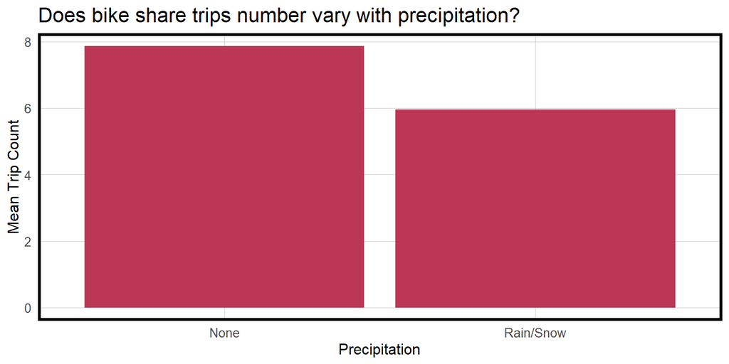

```r
st_drop_geometry(ride.panel.engineer) %>%
  group_by(interval60) %>%
  summarize(Trip_Count = mean(Trip_Count),
            Precipitation = first(Precipitation)) %>%
  mutate(isPrecip = ifelse(Precipitation > 0,"Rain/Snow", "None")) %>%
  group_by(isPrecip) %>%
  na.omit()%>%
  summarize(Mean_Trip_Count = mean(Trip_Count)) %>%
    ggplot(aes(isPrecip, Mean_Trip_Count)) +
    geom_bar(stat = "identity",fill=p5[3]) +
      labs(title="Does bike share trips number vary with precipitation?",
           x="Precipitation", y="Mean Trip Count") +
      plotTheme()
```

Other than Philadelphia, precipitation in NYC plays an important role in bike share, so it should be considered.

## 4. Training and validating

In this section, four linear regressions with different fixed effects are constructed.

1. `reg1` focuses on just time, including hour fixed effects, day of the week, and Temperature.
2. `reg2` focuses on just space effects with the exposure to amenities.
3. `reg3` includes both time and space fixed effects.
4. `reg4` adds the time lag features.

And `purrr` is used to train and validate these models for comparison on the latter two week test set.

```r
formula1 = Trip_Count ~  hour(interval60) + dotw + Temperature + Precipitation
formula2 = Trip_Count ~  expo.subway+expo.bus+expo.bike_route + dotw + Temperature + Precipitation
formula3 = Trip_Count ~  expo.subway+expo.bus+expo.bike_route + hour(interval60) + dotw + Temperature+Precipitation
formula4 = Trip_Count ~  expo.subway+expo.bus+expo.bike_route +  hour(interval60) + dotw + Temperature + lagHour + lag2Hours + lag3Hours + lag12Hours + lag1day + Precipitation

reg1 <- lm(formula1, data=ride.Train)
reg2 <- lm(formula2, data=ride.Train)
reg3 <- lm(formula3, data=ride.Train)
reg4 <- lm(formula4,  data=ride.Train)
```

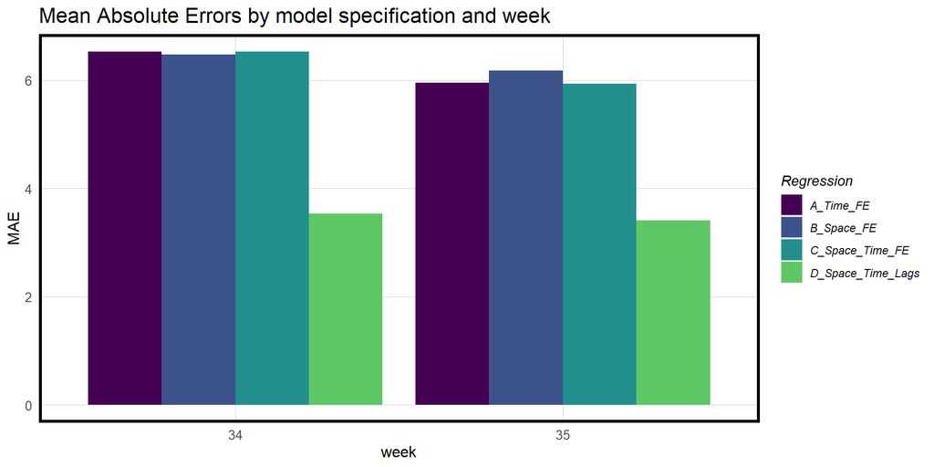

```r
model_pred <- function(dat, fit){
   pred <- predict(fit, newdata = dat)}

ride.Test.weekNest <-
  as.data.frame(ride.Test) %>%
  nest(-week)

week_predictions <-
  ride.Test.weekNest %>%
    mutate(A_Time_FE = map(.x = data, fit = reg1, .f = model_pred),
           B_Space_FE = map(.x = data, fit = reg2, .f = model_pred),
           C_Space_Time_FE = map(.x = data, fit = reg3, .f = model_pred),
           D_Space_Time_Lags = map(.x = data, fit = reg4, .f = model_pred))

mean.na = function(x) {mean(x,na.rm=T)}
 sd.na = function(x) {sd(x,na.rm=T)}

week_predictions <- week_predictions %>%
    gather(Regression, Prediction, -data, -week) %>%
    mutate(Observed = map(data, pull, Trip_Count),
           Absolute_Error = map2(Observed, Prediction,  ~ abs(.x - .y)),
           MAE = map_dbl(Absolute_Error, mean.na),
           sd_AE = map_dbl(Absolute_Error, sd.na))

week_predictions %>%
  dplyr::select(week, Regression, MAE) %>%
  gather(Variable, MAE, -Regression, -week) %>%
  ggplot(aes(week%>%as.factor(), MAE)) +
    geom_bar(aes(fill = Regression), position = "dodge", stat="identity") +
    scale_fill_manual(values = p5_2[1:4]) +
    labs(title = "Mean Absolute Errors by model specification and week",x="week") +
  plotTheme()
```

From the above regression above, it shows that the MAE of the Time LAG model is significantly smaller than other models, and its MAE is approximately 3.5, which has higher accuracy than other models. The impact of the Space variable is very limited to the overall accuracy of the model, which may be due to the small scale of the data source in the space, resulting in the small difference in spatial variables.

```r
stargazer::stargazer(reg1,reg2,reg3,reg4)
```

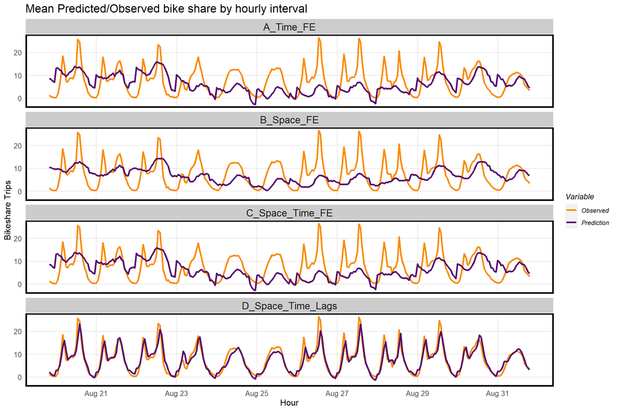

```r
week_predictions %>%
  mutate(interval60 = map(data, pull, interval60)) %>%
  dplyr::select(interval60, Observed, Prediction, Regression) %>%
  unnest() %>%
  gather(Variable, Value, -Regression, -interval60) %>%
    group_by(Regression, Variable, interval60) %>%
    summarize(Value = mean(Value)) %>%
    ggplot(aes(interval60, Value, colour=Variable)) + geom_line(size = 1.1) +
      facet_wrap(~Regression, ncol=1) +
      scale_colour_manual(values = p2) +
      labs(title = "Mean Predicted/Observed bike share by hourly interval",
           x = "Hour", y= "Bikeshare Trips") +
      plotTheme()
```

The prediction shows that the accuracy of the space_time_lags model is quite high and it manages to predict every peak and trough, which also brought the question of the model generizability. But from the perspective of this use case, this result is excellent.

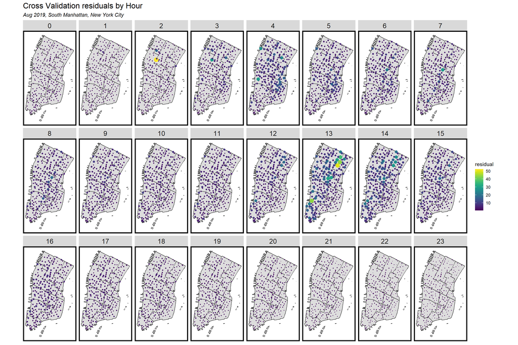

```r
library(caret)
fitControl <- caret::trainControl(method = "cv", number = 30)
set.seed(1)
reg.cv = caret::train(formula4, data = st_drop_geometry(ride.panel.engineer),
     method = "lm", trControl = fitControl, na.action = na.pass)

summary(reg.cv)
reg.cv.plot = ride.panel.engineer%>%
  st_sf(crs=crs)%>%
  na.omit()%>%
  mutate(residual=abs(residuals(reg.cv)),
         hour = hour(interval60))%>%
  group_by(start.station.id, hour)%>%
  summarise(residual=mean(residual))

reg.cv.plot%>%
  ggplot() +
  geom_sf(data=nbh,fill="#dddddd",color="#333333")+
  geom_sf(aes(color = residual,size=residual),shape = 19) +
  viridis::scale_color_viridis()+
  scale_size_continuous(range=c(0.1,4),guide ="none")+
  labs(title = "Cross Validation residuals by Hour",
       subtitle = "Aug 2019, South Manhattan, New York City") +
  facet_wrap(~hour,nrow=3)+
  mapTheme()
```

## 5. Conclude with how useful your algorithm is for the bike re-balancing plan.

This project has obtained an algorithm for the prediction of share-bike needs in Manhattan, New York City by comparing the different effects of different time and space variables. From the results of the analysis, I believe that the algorithm in this project is useful and should be put into practice. The accuracy of the algorithm has reached a relatively high level through the application of time lag and other variables, which means that in this use case, City-Bike can predict the user’s demand in time and space, so it can meet more user needs while increasing the utilization efficiency of shared bicycles. Of course, the model can be further optimized:

1. Generizability: Since this project is limited to South Manhattan because of limited computing power, the scope of the algorithm itself has bias, and its generizability needs further study.
2. Space autocorrelation: From the results of Cross-Validation, in the peak hours, the model residuals have spatially autocorrelation. In practical use, such results may cause problems with insufficient truck schedules. This shows that in this algorithm, space-related exposure still needs to be added.

# Related Links

1. https://en.wikipedia.org/wiki/Bicycle-sharing_system
2. https://www.nydailynews.com/new-york/ny-citi-bike-manhattan-bike-sharing-20210407-fxt2jsgokfhkbldon4tvbkte7u-story.html
3. https://www.nydailynews.com/new-york/ny-nyc-cycling-bike-counts-east-river-bridges-20201201-qbqdfh2hs5bfxf7p7b53okrnsi-story.html